# Group 3

Kaylen, Veronica, Lyndsey, Jadyn, Kingsley

2025-12-03

## Introduction

A Florida county-level dataset from the U.S. COVID-19 library, which includes variables such as new percent positive cases, deaths, testing rates, and median age, to explore factors related to infection rates.

Our research questions were:

How did major COVID-19 discussion topics and sentiments shift across different stages of the pandemic?

Which county-level factors best predict new percent positive COVID-19 rates in Florida?

```r
# EVERYONE LOAD YOUR LIBRARIES HERE. DO NOT DUPLICATE.
library(tidyverse)
library(tidytext)
library(topicmodels)
```

```r
library(ggplot2)
library(textclean)
library(tm)
library(SnowballC)
library(shiny)
library(readr)
library(skimr)
library(lubridate)
library(textstem)
```

## Exploratory Analysis

For this exploratory analysis, I used a Shiny app to visualoze COVID-19 data accross Florida Counties. I selected the most relevant variables such as cases, deaths, testing, monitoring, and median age. I also removed missing values to make sure there would be no erros. Through the usage of Shiny app, I was able to compare metrics interactively through bar charts, histograms, and scatter plots. I was able to find that larger urban counties had the highest total cases, but small rural counties had higher positivity rates, suggesting that county density and testing capacity play a role in detecting cases. Scatterplots comparing median age and deaths showed that older, more populous counties showed mortality.

```r
fl <- read_csv(
  "data/Florida_COVID19_10302020_ByCounty_CSV_Partial.csv",
  show_col_types = FALSE
) |>
  filter(COUNTYNAME != "A State") |>
  transmute(
    county = COUNTYNAME,      # nicer name for UI
    NewPercPos,               # new percent positive
    NewTested,                # count new tests
    NewPos,                   # count new positives
    T_positive,               # cumulative positives
    T_negative,               # cumulative negatives
    Deaths,                   # cumulative deaths
    MedianAge,                # county median age
    EverMon,                  # ever monitored
    MonNow                    # monitored now
  ) |>
  na.omit()

#Shared labels for UI controls
#Named vector: user-facing labels on the left, column names on the right.
metric_choices <- c(
  "New percent positive" = "NewPercPos",
  "New tested"           = "NewTested",
  "New positives"        = "NewPos",
  "Total positives"      = "T_positive",
  "Total negatives"      = "T_negative",
  "Deaths"               = "Deaths",
  "Median age"           = "MedianAge",
  "Ever monitored"       = "EverMon",
  "Monitored now"        = "MonNow"
)

#Small helper to convert a selected column name back to its label
label_for <- function(var) names(metric_choices)[metric_choices == var]

#UI
ui <- fluidPage(
  titlePanel("Florida COVID-19 by County — Explorer"),
  sidebarLayout(
    sidebarPanel(
      #Overview (bar + dist) controls
      selectInput("metric", "Metric:", choices = metric_choices, selected = "NewPercPos"),
      sliderInput("topN", "Show top N counties:", min = 5, max = 25, value = 10, step = 1),
      tags$hr(),
      #Compare (scatter) controls
      selectInput("xvar",     "X-axis:",     choices = metric_choices, selected = "MedianAge"),
      selectInput("yvar",     "Y-axis:",     choices = metric_choices, selected = "NewPercPos"),
      selectInput("sizevar",  "Point size:", choices = metric_choices, selected = "NewTested"),
      selectInput("colorvar", "Point color:",choices = metric_choices, selected = "MedianAge")
    ),
    mainPanel(
      tabsetPanel(
        tabPanel("Overview (Top Counties)", plotOutput("barTop", height = "360px")),
        tabPanel("Distribution",            plotOutput("distPlot", height = "360px")),
        tabPanel("Compare (Scatter)",       plotOutput("scatter", height = "420px")),
        tabPanel("Table",                   tableOutput("tbl"))
      )
    )
  )
)

#Server
server <- function(input, output){

  #Top-N bar chart of the selected metric
  output$barTop <- renderPlot({
    #Rank counties by selected metric and keep the top N
    df <- fl |>
      arrange(desc(.data[[input$metric]])) |>
      slice_head(n = input$topN) |>
      mutate(county = reorder(county, .data[[input$metric]]))  #order bars

    p <- ggplot(df, aes(x = county, y = .data[[input$metric]])) +
      geom_col(fill = "#2c7fb8") +
      coord_flip() +
      labs(
        title = paste0("Top ", input$topN, " counties by ", label_for(input$metric)),
        x = NULL,
        y = label_for(input$metric)
      ) +
      theme_minimal(base_size = 13)

    p
  })

  #Distribution (histogram + density) of the selected metric
  output$distPlot <- renderPlot({
    p <- ggplot(fl, aes(x = .data[[input$metric]])) +
      geom_histogram(bins = 30, alpha = 0.7) +     # histogram for frequency
      geom_density(linewidth = 1) +                # smoothed shape overlay
      labs(
        title = paste0("Distribution of ", label_for(input$metric)),
        x = label_for(input$metric),
        y = "Count"
      ) +
      theme_minimal(base_size = 13)
    p
  })

  #Scatter: compare any two metrics, with size/color encodings
  output$scatter <- renderPlot({
    p <- ggplot(
      fl,
      aes(
        x     = .data[[input$xvar]],
        y     = .data[[input$yvar]],
        size  = .data[[input$sizevar]],   # third variable via point size
        color = .data[[input$colorvar]]   # fourth variable via color
      )
    ) +
      geom_point(alpha = 0.85) +
      scale_size_continuous(range = c(2, 10)) +
      labs(
        title = "Compare two metrics by county",
        x     = label_for(input$xvar),
        y     = label_for(input$yvar),
        size  = label_for(input$sizevar),
        color = label_for(input$colorvar)
      ) +
      theme_minimal(base_size = 13)
    p
  })

  #Preview table
  output$tbl <- renderTable({
    head(fl, 12)
  })
}

#Run app
shinyApp(ui = ui, server = server)
```

Shiny applications not supported in static R Markdown documents

## Linear Regression

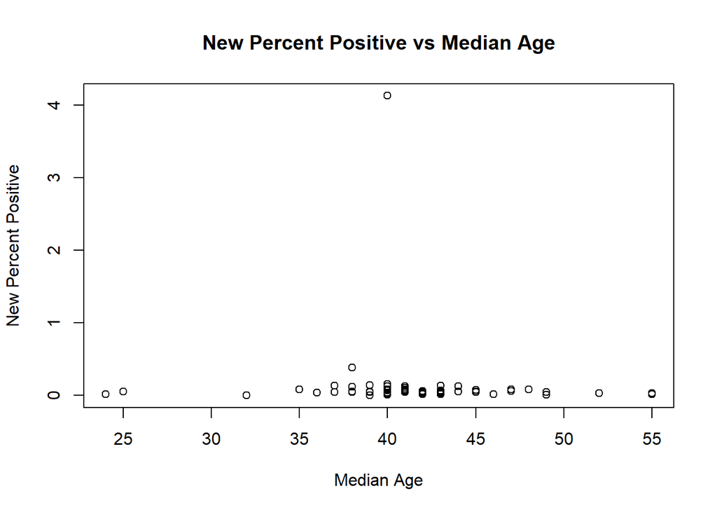

```r
# Loaded packages are above


# Read the dataset
myDF <- read.csv("data/Florida_COVID19_10302020_ByCounty_CSV_Partial.csv")



# Keep relevant variables
myDF2 <- myDF[, c("COUNTYNAME",
                  "NewPercPos",
                  "MedianAge",
                  "EverMon",
                  "MonNow")]

# Remove missing values
myDF2 <- na.omit(myDF2)

# Scatterplot of New Percent Positive vs Median Age
plot(myDF2$MedianAge, myDF2$NewPercPos,
     xlab = "Median Age",
     ylab = "New Percent Positive",
     main = "New Percent Positive vs Median Age")
```

```r
# Linear regression model
lm1 <- lm(NewPercPos ~ MedianAge + EverMon + MonNow, data = myDF2)

# Model summary
summary(lm1)
```

```
##
## Call:
## lm(formula = NewPercPos ~ MedianAge + EverMon + MonNow, data = myDF2)
##
## Residuals:
##      Min       1Q   Median       3Q      Max
## -0.27668 -0.03532  0.00988  0.03797  0.37006
##
## Coefficients:
##               Estimate Std. Error t value Pr(>|t|)
## (Intercept) -1.740e-02  9.785e-02  -0.178    0.859
## MedianAge    4.901e-04  2.344e-03   0.209    0.835
## EverMon      1.760e-04  3.843e-05   4.581 2.15e-05 ***
## MonNow      -1.707e-04  3.989e-05  -4.279 6.30e-05 ***
## ---
## Signif. codes:  0 '***' 0.001 '**' 0.01 '*' 0.05 '.' 0.1 ' ' 1
##
## Residual standard error: 0.09668 on 65 degrees of freedom
## Multiple R-squared:  0.9633, Adjusted R-squared:  0.9616
## F-statistic:   568 on 3 and 65 DF,  p-value: < 2.2e-16
```

```r
# Simpler model
lm2 <- lm(NewPercPos ~ MedianAge, data = myDF2)
summary(lm2)
```

```
##
## Call:
## lm(formula = NewPercPos ~ MedianAge, data = myDF2)
##
## Residuals:
##     Min      1Q  Median      3Q     Max
## -0.1778 -0.0859 -0.0646 -0.0406  4.0072
##
## Coefficients:
##              Estimate Std. Error t value Pr(>|t|)
## (Intercept)  0.298293   0.500720   0.596    0.553
## MedianAge   -0.004314   0.012015  -0.359    0.721
##
## Residual standard error: 0.4963 on 67 degrees of freedom
## Multiple R-squared:  0.00192,    Adjusted R-squared:  -0.01298
## F-statistic: 0.1289 on 1 and 67 DF,  p-value: 0.7207
```

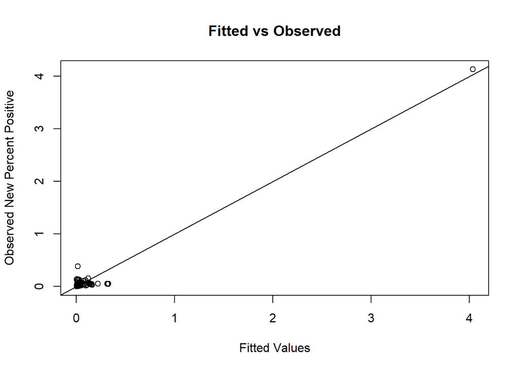

```r
# Fitted vs Observed plot
plot(fitted(lm1), myDF2$NewPercPos,
     xlab = "Fitted Values",
     ylab = "Observed New Percent Positive",
     main = "Fitted vs Observed")
abline(0, 1)
```

## Sentiment Analysis

This sentiment analysis focused on Florida-based COVID-19 tweets to examine how public mood changed over time. Once the text was processed for analysis and cleaned, tweets were deemed positive or negative according to the Bing sentiment dictionary. Results indicated that public sentiment was tied to major changes in the major pandemic events like case surges and reopenings and vaccine rollout. Overall, the analysis showed that sentiment analysis is useful for tracking public mood.

```r
# Loads libraries
tweets_apr_jun <- read_csv("data/COVIDTweetsAprilToJune2020.csv")
tweets_aug_sep <- read_csv("data/COVIDTweetsAprilToJune2021.csv")
tweets <- bind_rows(tweets_apr_jun, tweets_aug_sep)

# Convert created_at to date
tweets <- tweets %>%
  mutate(date = as.Date(created_at, format = "%m/%d/%Y"),
         month = floor_date(date, "month"))   # add month column

# Filters for tweets in Florida
tweets_fl <- tweets %>%
  filter(str_detect(place, regex("Florida", ignore_case = TRUE)))

# Loads Bing sentiment dictionary
bing <- get_sentiments("bing")
data("stop_words")

# Tokenize and join with Bing
joined_fl <- tweets_fl %>%
  unnest_tokens(word, clean_tweet) %>%
  mutate(word = str_to_lower(word)) %>%
  mutate(word = lemmatize_words(word)) %>%
  filter(str_detect(word, "^[a-z]+$")) %>%
  anti_join(stop_words, by = "word") %>%
  inner_join(bing, by = "word")

# Exploratory Analysis

# Quick overview
skim(tweets)
```

Data summary

| Name | tweets |
| --- | --- |
| Number of rows | 291378 |
| Number of columns | 19 |
| _______________________ |  |
| Column type frequency: |  |
| character | 9 |
| Date | 3 |
| numeric | 7 |
| ________________________ |  |
| Group variables | None |

**Variable type: character**

| skim_variable | n_missing | complete_rate | min | max | empty | n_unique | whitespace |
| --- | --- | --- | --- | --- | --- | --- | --- |
| source | 27 | 1.00 | 48 | 157 | 0 | 2713 | 0 |
| original_text | 1 | 1.00 | 8 | 197 | 0 | 291314 | 0 |
| lang | 2 | 1.00 | 2 | 2 | 0 | 1 | 0 |
| original_author | 2 | 1.00 | 2 | 16 | 0 | 227485 | 0 |
| hashtags | 224449 | 0.23 | 1 | 121 | 0 | 35006 | 0 |
| user_mentions | 83409 | 0.71 | 1 | 134 | 0 | 119259 | 0 |
| place | 83787 | 0.71 | 1 | 148 | 0 | 56237 | 2 |
| clean_tweet | 1433 | 1.00 | 2 | 125 | 0 | 269493 | 0 |
| sentiment | 0 | 1.00 | 3 | 3 | 0 | 3 | 0 |

**Variable type: Date**

| skim_variable | n_missing | complete_rate | min | max | median | n_unique |
| --- | --- | --- | --- | --- | --- | --- |
| created_at | 1 | 1 | 2020-04-19 | 2021-06-27 | 2021-04-26 | 105 |
| date | 1 | 1 | 2020-04-19 | 2021-06-27 | 2021-04-26 | 105 |
| month | 1 | 1 | 2020-04-01 | 2021-06-01 | 2021-04-01 | 6 |

**Variable type: numeric**

| skim_variable | n_missing | complete_rate | mean | sd | p0 | p25 | p50 | p75 | p100 | hist |
| --- | --- | --- | --- | --- | --- | --- | --- | --- | --- | --- |
| id | 2 | 1 | 1.329941e+18 | 6.923536e+16 | 1.25e+18 | 1.26e+18 | 1.386744e+18 | 1.398644e+18 | 1.40914e+18 | ▇▁▁▁▇ |
| favorite_count | 2 | 1 | 2.300000e-01 | 7.130000e+00 | 0.00e+00 | 0.00e+00 | 0.000000e+00 | 0.000000e+00 | 2.92300e+03 | ▇▁▁▁▁ |
| retweet_count | 2 | 1 | 1.182300e+03 | 7.522510e+03 | 0.00e+00 | 1.00e+00 | 1.300000e+01 | 1.890000e+02 | 3.99220e+05 | ▇▁▁▁▁ |
| compound | 0 | 1 | 1.000000e-02 | 3.700000e-01 | -9.90e-01 | -1.00e-01 | 0.000000e+00 | 2.500000e-01 | 9.80000e-01 | ▂▂▇▃▁ |
| neg | 0 | 1 | 9.000000e-02 | 1.500000e-01 | 0.00e+00 | 0.00e+00 | 0.000000e+00 | 1.800000e-01 | 1.00000e+00 | ▇▂▁▁▁ |
| neu | 0 | 1 | 8.100000e-01 | 2.000000e-01 | 0.00e+00 | 6.70e-01 | 8.200000e-01 | 1.000000e+00 | 1.00000e+00 | ▁▁▂▅▇ |
| pos | 0 | 1 | 1.000000e-01 | 1.600000e-01 | 0.00e+00 | 0.00e+00 | 0.000000e+00 | 2.000000e-01 | 1.00000e+00 | ▇▂▁▁▁ |

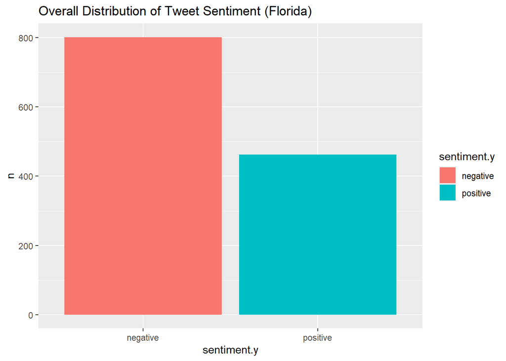

```r
# Overall sentiment distribution
joined_fl %>%
  count(sentiment.y) %>%
  ggplot(aes(x = sentiment.y, y = n, fill = sentiment.y)) +
  geom_col() +
  labs(title = "Overall Distribution of Tweet Sentiment (Florida)")
```

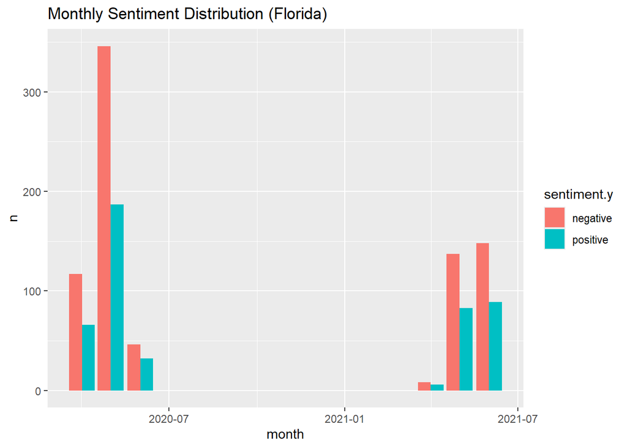

```r
# Monthly sentiment distribution
joined_fl %>%
  count(month, sentiment.y) %>%
  ggplot(aes(x = month, y = n, fill = sentiment.y)) +
  geom_col(position = "dodge") +
  labs(title = "Monthly Sentiment Distribution (Florida)")
```

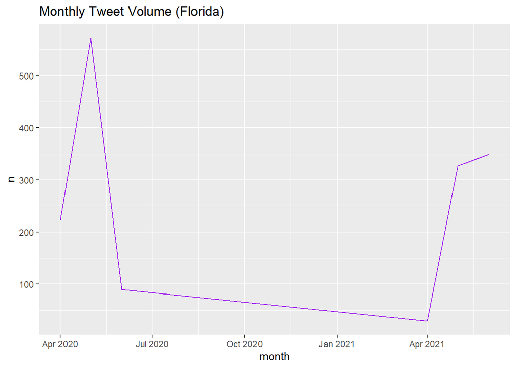

```r
# Monthly tweet volume
tweets_fl %>%
  filter(!is.na(month)) %>%
  count(month) %>%
  ggplot(aes(x = month, y = n)) +
  geom_line(color = "purple") +
  labs(title = "Monthly Tweet Volume (Florida)")
```

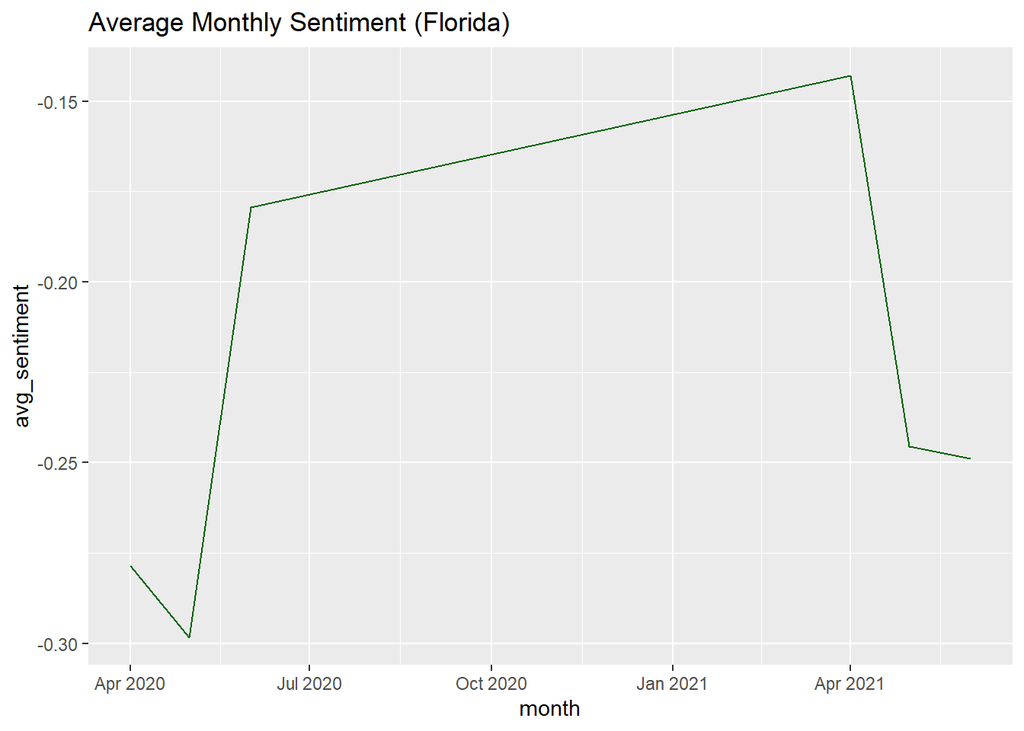

```r
# Average monthly sentiment score
monthly_sentiment_fl <- joined_fl %>%
  mutate(sentiment_score = ifelse(sentiment.y == "positive", 1, -1)) %>%
  group_by(month) %>%
  summarise(
    avg_sentiment = mean(sentiment_score, na.rm = TRUE),
    tweet_volume = n()
  )

ggplot(monthly_sentiment_fl, aes(x = month, y = avg_sentiment)) +
  geom_line(color = "darkgreen") +
  labs(title = "Average Monthly Sentiment (Florida)")
```

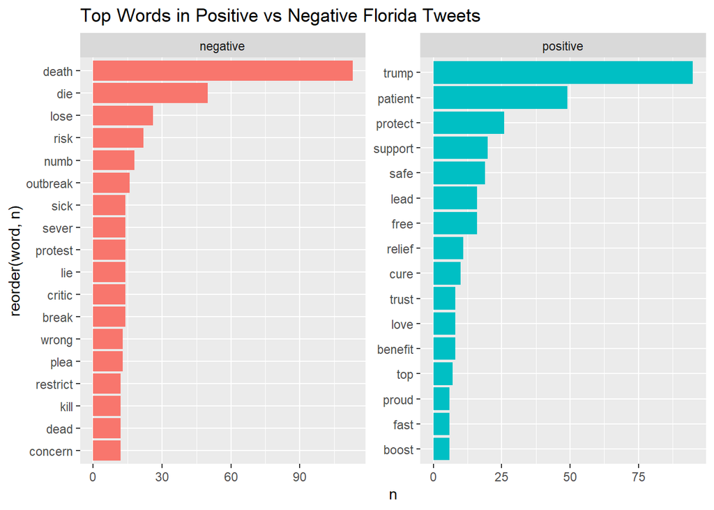

```r
# Top words in positive vs negative tweets
top_words_fl <- joined_fl %>%
  count(sentiment.y, word, sort = TRUE) %>%
  group_by(sentiment.y) %>%
  slice_max(n, n = 15)

ggplot(top_words_fl, aes(x = reorder(word, n), y = n, fill = sentiment.y)) +
  geom_col(show.legend = FALSE) +
  facet_wrap(~sentiment.y, scales = "free") +
  coord_flip() +
  labs(title = "Top Words in Positive vs Negative Florida Tweets")
```

## Topic Modeling

The goal is to compare topics and themes discussed revolving around COVID-19 during April-June of 2020 and April-June of 2021—a one year difference.

**I created my own customs words.** Some of the words are obvious topic words, such as “covid19” which would become redundant. Others include numbers that didn’t get cleaned out with my cleaning functions and some other words that add no value to the topic-naming stage via beta scores.

```r
more_stop_words <- tribble(
  ~word, ~lexicon,
  "covid19", "CUSTOM",
  "coronavirus", "CUSTOM",
  "rt", "CUSTOM",
  "covid", "CUSTOM",
  "19", "CUSTOM",
  "florida", "CUSTOM",
  "coronaviru", "CUSTOM",
  "http", "CUSTOM",
  "covidnineteen", "CUSTOM",
  "don’t", "CUSTOM",
  "it’s", "CUSTOM",
  "hundreds", "CUSTOM",
  "thousands", "CUSTOM",
  "millions", "CUSTOM",
  "thousandth", "CUSTOM",
  "fauci", "CUSTOM",
  "amp", "CUSTOM",
  "port", "CUSTOM",
  "due", "CUSTOM",
  "stainless", "CUSTOM",
  "include", "CUSTOM",
  "video", "CUSTOM",
  "dyannleroy", "CUTSOM",
  "ten", "CUSTOM",
  "million", "CUSTOM",
  "di", "CUSTOM",
  "pm", "CUSTOM",
  "dianeswonk", "CUSTOM",
  "residency", "CUSTOM"
)

full_stop_words <- stop_words %>%
  bind_rows(more_stop_words)
```

### April to June of 2020 - Preparing my data

- I loaded in my data, assigned unique ids, cleaned the tweets, tokenized my documents, performed word stemming and stem completion, the counted words per id.

```r
  data2020 <- read.csv("data/COVIDTweetsAprilToJune2020.csv")

  original_2020 <- data2020 %>%
    filter(str_detect(place, "Florida|FL")) %>%
    select(id, original_text) %>%
    mutate(id = row_number()) # Reassign unique ids because the scientific notation made documents appears to be the same docs/source.

  # cleaning 2020 original tweets FROM SCRATCH
  clean2020 <- original_2020 %>%
    mutate(original_text = as.character(original_text)) %>%
    mutate(original_text = replace_contraction(original_text)) %>%
    mutate(original_text = replace_number(original_text)) %>%
    mutate(original_text = str_remove_all(original_text, "https?://.*$")) %>%
    mutate(original_text = str_remove_all(original_text, "RT ")) %>%
    mutate(original_text = str_remove_all(original_text, "@\\w+")) %>%
    mutate(original_text = removePunctuation(original_text)) %>%
    mutate(original_text = str_remove_all(original_text, "'")) %>%
    mutate(original_text = removeNumbers(original_text)) %>%
    unnest_tokens(word, original_text) %>%
    anti_join(full_stop_words)
  dictionary_2020 <- original_2020 %>%
    select(original_text) %>%
    unnest_tokens(word, original_text) %>%
    anti_join(full_stop_words) %>%
    distinct(word) %>%
    pull(word)
  # This dictionary will be used to stem-complete the words after I stem them.

  stem2020 <- clean2020 %>%
    mutate(word = wordStem(word)) %>%
    mutate(
      word = unlist(lapply(word, stemCompletion, dictionary = dictionary_2020))
    )
  # The words did not 100% stem the way I had hoped, so I manually fixed some of them after searching/filtering through the original tweets to find the best match if needed. I repeat these same words for manual stem completion in the 2021 data processing (next) too. Still, stem completion saved a lot of time and cleaned up the data well enough.
  words_2020 <- stem2020 %>%
    drop_na() %>%
    anti_join(full_stop_words) %>%
    mutate(word = recode(word,
                         "viru" = "virus",
                         "informat" = "information",
                         "posit" = "positive",
                         "mani" = "humanity",
                         "commun" = "community",
                         "preside" = "president",
                         "respons" = "response",
                         "raise" = "fundraise",
                         "busin" = "business",
                         "hospita" = "hospital",
                         "vaccin" = "vaccine",
                         "accounc" = "announce",
                         "countie" = "county",
                         "populati" = "population",
                         "emerge" = "emergency",
                         "announc" = "announce",
                         "updat" = "update")) %>%
    count(id, word)
```

### Creating the 2020 LDA model:

```r
  # LDA Modeling
  dtm2020 <- words_2020 %>%
    cast_dtm(id, word, n)

  lda2020_k9 = LDA(
    dtm2020,
    k = 9, # After many trial and errors, I found this k value to be the most humanly interpret-able for the 2020 covid data.
    method = "Gibbs",
    control = list(seed = 67)
  )

  glimpse(lda2020_k9)
```

```
## Formal class 'LDA_Gibbs' [package "topicmodels"] with 16 slots
##   ..@ seedwords      : NULL
##   ..@ z              : int [1:12362] 5 3 3 5 1 7 6 5 4 3 ...
##   ..@ alpha          : num 5.56
##   ..@ call           : language LDA(x = dtm2020, k = 9, method = "Gibbs", control = list(seed = 67))
##   ..@ Dim            : int [1:2] 1787 3698
##   ..@ control        :Formal class 'LDA_Gibbscontrol' [package "topicmodels"] with 14 slots
##   ..@ k              : int 9
##   ..@ terms          : chr [1:3698] "claim" "gov" "left" "medicareforall" ...
##   ..@ documents      : chr [1:1787] "1" "2" "3" "4" ...
##   ..@ beta           : num [1:9, 1:3698] -9.78 -9.75 -9.76 -9.77 -5.48 ...
##   ..@ gamma          : num [1:1787, 1:9] 0.1171 0.0926 0.113 0.1214 0.101 ...
##   ..@ wordassignments:List of 5
##   .. ..$ i   : int [1:12078] 1 1 1 1 1 1 2 2 2 2 ...
##   .. ..$ j   : int [1:12078] 1 2 3 4 5 6 7 8 9 10 ...
##   .. ..$ v   : num [1:12078] 5 3 3 5 1 7 9 9 4 3 ...
##   .. ..$ nrow: int 1787
##   .. ..$ ncol: int 3698
##   .. ..- attr(*, "class")= chr "simple_triplet_matrix"
##   ..@ loglikelihood  : num -86996
##   ..@ iter           : int 2000
##   ..@ logLiks        : num(0)
##   ..@ n              : int 12362
```

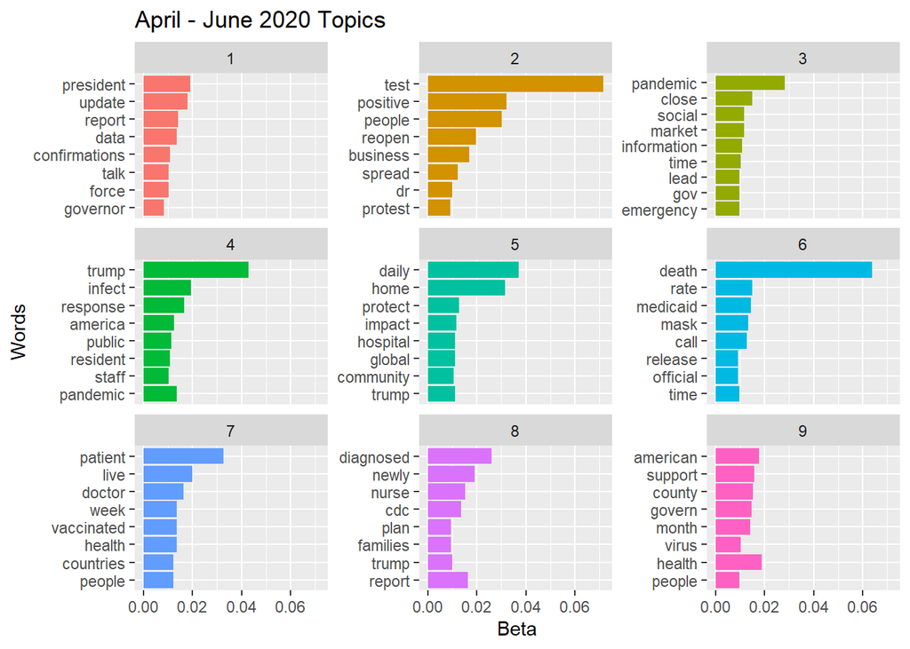

```r
  beta_2020_k9 <- lda2020_k9 %>%
    tidy(matrix = "beta") # Beta to find out the words within a topic to analyze them.

  beta_2020_k9 <- beta_2020_k9 %>%
    arrange(desc(beta)) %>%
    group_by(topic) %>%
    slice_max(beta, n = 8) %>% # 8 words at a time in a column chart, but if any beta values tie, they will both (or more) show, which is fine.
    mutate(term2 = fct_reorder(term, beta))

  ggplot(beta_2020_k9, aes(term2, beta, fill = as.factor(topic))) +
    geom_col(show.legend = F) +
    facet_wrap(~topic, scales = "free_y") + # free_y scale so that the beta ticks change in the same increments across plots.
    coord_flip() +
    labs(title = "April - June 2020 Topics",
         x = "Words",
         y = "Beta")
```

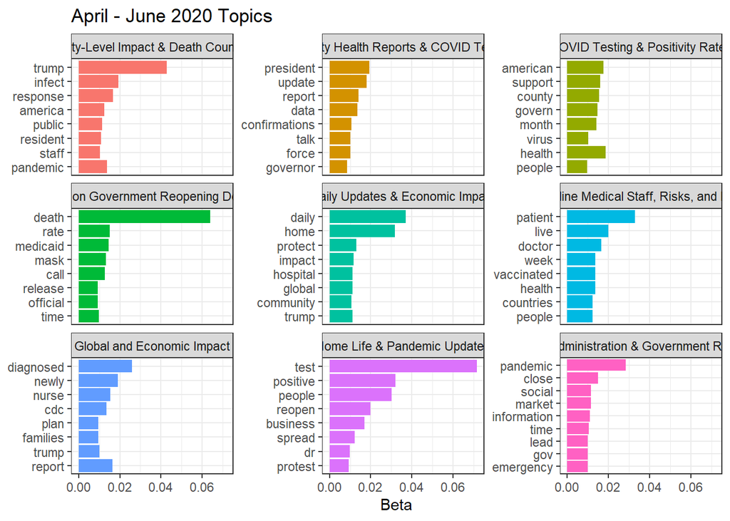

```r
  # Labeling human-identified topics using k = 9
  beta_2020_k9 <- beta_2020_k9 %>%
    mutate(
      topic = as.character(topic),
      topic = recode(topic,
                     "1" = "County Health Reports & COVID Testing",
                     "2" = "Home Life & Pandemic Updates",
                     "3" = "Trump Administration & Government Response",
                     "4" = "City-Level Impact & Death Counts",
                     "5" = "Daily Updates & Economic Impact",
                     "6" = "Critique on Government Reopening Decisions",
                     "7" = "Frontline Medical Staff, Risks, and Plans",
                     "8" = "Global and Economic Impact",
                     "9" = "COVID Testing & Positivity Rates"))

  # Re-plot w/ topic titles
  ggplot(beta_2020_k9, aes(term2, beta, fill = as.factor(topic))) +
    geom_col(show.legend = F) +
    facet_wrap(~topic, scales = "free_y") +
    coord_flip() +
    labs(title = "April - June 2020 Topics",
         x = NULL,
         y = "Beta") + theme_bw()
```

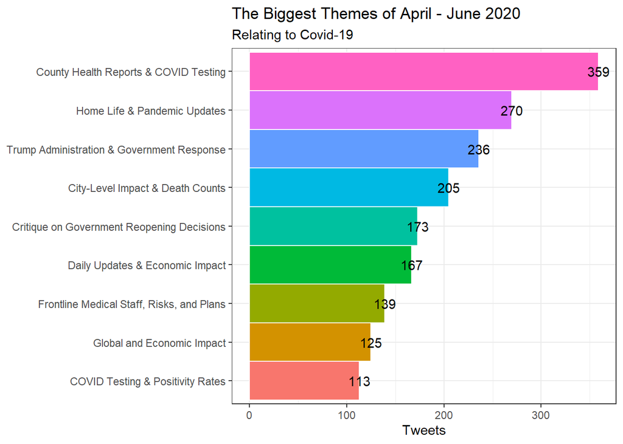

```r
  # gamma to find most dominant/prevalent topic during 2020
  gamma_2020_k16 <- lda2020_k9 %>%
    tidy(matrix = "gamma") %>%
    mutate(
      topic = recode(topic,
                     "1" = "County Health Reports & COVID Testing",
                     "2" = "Home Life & Pandemic Updates",
                     "3" = "Trump Administration & Government Response",
                     "4" = "City-Level Impact & Death Counts",
                     "5" = "Daily Updates & Economic Impact",
                     "6" = "Critique on Government Reopening Decisions",
                     "7" = "Frontline Medical Staff, Risks, and Plans",
                     "8" = "Global and Economic Impact",
                     "9" = "COVID Testing & Positivity Rates"))

  dominant_topic_2020 <- gamma_2020_k16 %>%
    group_by(document) %>%
    slice_max(gamma, n = 1, with_ties = FALSE) %>%
    ungroup() # finding the best fit topic per document

  topic_counts_2020 <- dominant_topic_2020 %>%
    count(topic, sort = TRUE) %>%
    mutate(topic = reorder(topic, n)) # adding up documents per topic

  # Bar charts > Pie charts
  ggplot(topic_counts_2020, aes(x = topic, y = n, fill = topic)) +
    geom_bar(stat = "identity", width = 1, color = "white", show.legend = F) +
    geom_text(aes(label = n)) +
    coord_flip() +
    labs(
      title = "The Biggest Themes of April - June 2020",
      subtitle = "Relating to Covid-19",
      fill = "Themes",
      x = NULL,
      y = "Tweets"
    ) + theme_bw()
```

**For context**: Early April, the CDC announced new mask-wearing guidelines. Many people complied; current President Trump did not. Florida ended quarantine on April 30th and moved into phases of reopening the public. In early June, the state had entered phase two of reopening, meaning allowing bars, theaters, and other public building spaces to run at 50% capacity. There was no vaccine yet, but development, research, and human clinical trials had been ongoing and fast.

*More can be found here:* https://www.cdc.gov/museum/timeline/covid19.html

Overall, many of the tweets consisted of reporting official news, health guidelines and also a lot of conversations around these new experiences, such as the entire pandemic and home life. Reopening after quarantine, some people were precautious and others were tired of quarantine and masks.

One topic that I found interesting and nostalgic (but I changed the model since I made a *major* preprocessing error) was something Jadyn and I labeled as *Community Support for Healthcare Workers*. After code revisions and changes in the k value, that topic was never seen or at least obvious again.

### April to June of 2021 - Preparing my data and running an LDA model

I basically repeat most of the code I did for the 2020 data with the 2021 data, switching out and renaming new objects.

```r
 data2021 <- read.csv("data/COVIDTweetsAprilToJune2021.csv")

  original_2021 <- data2021 %>%
    filter(str_detect(place, "Florida|FL")) %>%
    select(id, original_text) %>%
    mutate(id = row_number())

  # cleaning 2021 original tweets FROM SCRATCH
  clean2021 <- original_2021 %>%
    mutate(original_text = as.character(original_text)) %>%
    mutate(original_text = replace_contraction(original_text)) %>%
    mutate(original_text = replace_number(original_text)) %>%
    mutate(original_text = str_remove_all(original_text, "https?://.*$")) %>%
    mutate(original_text = str_remove_all(original_text, "RT ")) %>%
    mutate(original_text = str_remove_all(original_text, "@\\w+")) %>%
    mutate(original_text = removePunctuation(original_text)) %>%
    mutate(original_text = str_remove_all(original_text, "'")) %>%
    mutate(original_text = removeNumbers(original_text)) %>%
    unnest_tokens(word, original_text) %>%
    anti_join(full_stop_words)
  dictionary_2021 <- original_2021 %>%
    select(original_text) %>%
    unnest_tokens(word, original_text) %>%
    anti_join(full_stop_words) %>%
    distinct(word) %>%
    pull(word)
  stem2021 <- clean2021 %>%
    mutate(word = wordStem(word)) %>%
    mutate(
      word = unlist(lapply(word, stemCompletion, dictionary = dictionary_2021))
    )

  words_2021 <- stem2021 %>%
    drop_na() %>%
    anti_join(full_stop_words) %>%
    mutate(word = recode(word,
                         "viru" = "virus",
                         "informat" = "information",
                         "posit" = "positive",
                         "mani" = "humanity",
                         "communi" = "community",
                         "preside" = "president",
                         "respons" = "response",
                         "raise" = "fundraise",
                         "busin" = "business",
                         "hospita" = "hospital",
                         "vaccin" = "vaccine",
                         "accounc" = "announce",
                         "countie" = "county",
                         "populati" = "population",
                         "emerge" = "emergency",
                         "announc" = "announce",
                         "updat" = "update",
                         "requir" = "require")) %>%
    count(id, word)
  # LDA Modeling
  dtm2021 <- words_2021 %>%
    cast_dtm(id, word, n)

  lda2021_k10 = LDA(
    dtm2021,
    k = 8,
    method = "Gibbs",
    control = list(seed = 10)
  )

  glimpse(lda2021_k10)
```

```
## Formal class 'LDA_Gibbs' [package "topicmodels"] with 16 slots
##   ..@ seedwords      : NULL
##   ..@ z              : int [1:9871] 5 5 7 4 7 2 4 1 8 1 ...
##   ..@ alpha          : num 6.25
##   ..@ call           : language LDA(x = dtm2021, k = 8, method = "Gibbs", control = list(seed = 10))
##   ..@ Dim            : int [1:2] 1399 3129
##   ..@ control        :Formal class 'LDA_Gibbscontrol' [package "topicmodels"] with 14 slots
##   ..@ k              : int 8
##   ..@ terms          : chr [1:3129] "allowed" "american" "break" "european" ...
##   ..@ documents      : chr [1:1399] "1" "2" "3" "4" ...
##   ..@ beta           : num [1:8, 1:3129] -9.64 -9.68 -9.64 -9.68 -5.52 ...
##   ..@ gamma          : num [1:1399, 1:8] 0.123 0.174 0.129 0.123 0.132 ...
##   ..@ wordassignments:List of 5
##   .. ..$ i   : int [1:9650] 1 1 1 1 1 1 1 1 1 2 ...
##   .. ..$ j   : int [1:9650] 1 2 3 4 5 6 7 8 9 10 ...
##   .. ..$ v   : num [1:9650] 5 4 2 4 7 2 4 1 8 1 ...
##   .. ..$ nrow: int 1399
##   .. ..$ ncol: int 3129
##   .. ..- attr(*, "class")= chr "simple_triplet_matrix"
##   ..@ loglikelihood  : num -68258
##   ..@ iter           : int 2000
##   ..@ logLiks        : num(0)
##   ..@ n              : int 9871
```

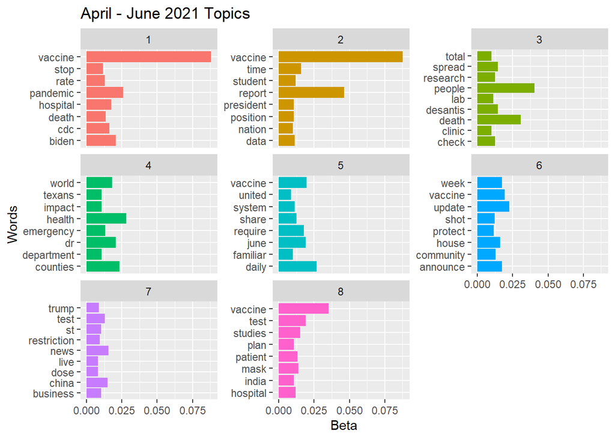

```r
  beta_2021_k10 <- lda2021_k10 %>%
    tidy(matrix = "beta")

  beta_2021_k10 <- beta_2021_k10 %>%
    arrange(desc(beta)) %>%
    group_by(topic) %>%
    slice_max(beta, n = 8) %>%
    mutate(term2 = fct_reorder(term, beta))

  ggplot(beta_2021_k10, aes(term, beta, fill = as.factor(topic))) +
    geom_col(show.legend = F) +
    facet_wrap(~topic, scales = "free_y") +
    coord_flip() +
    labs(
      title = "April - June 2021 Topics",
      x = "Words",
      y = "Beta"
    )
```

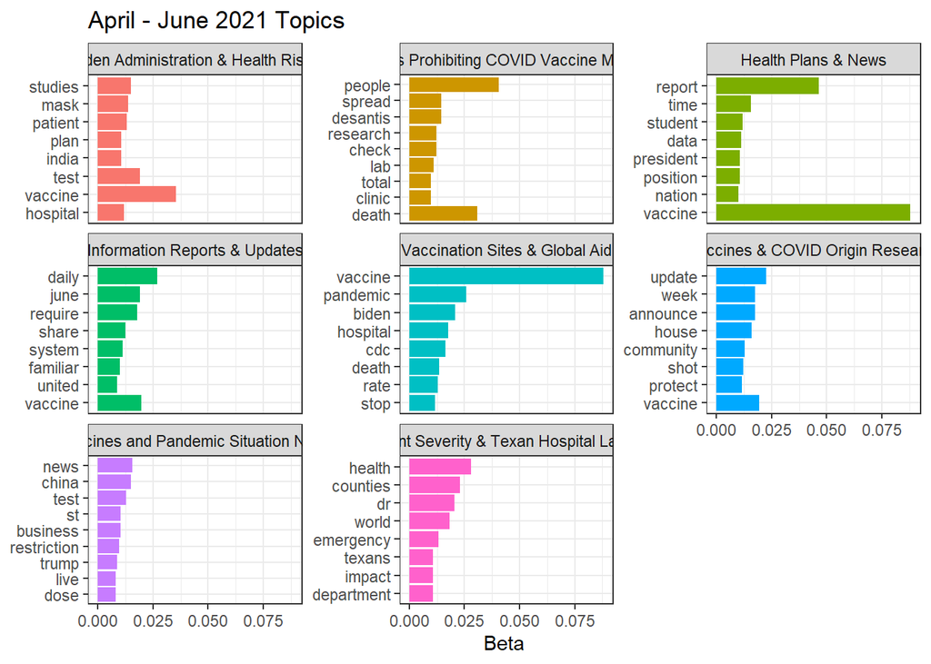

```r
  # Labeling human-identified topics using k = 10
  beta_2021_k10 <- beta_2021_k10 %>%
    mutate(
      topic = as.character(topic),
      topic = recode(topic,
                     "1" = "Vaccination Sites & Global Aid",
                     "2" = "Health Plans & News",
                     "3" = "Desantis Prohibiting COVID Vaccine Mandates",
                     "4" = "Variant Severity & Texan Hospital Lawsuit",
                     "5" = "Information Reports & Updates",
                     "6" = "Vaccines & COVID Origin Research",
                     "7" = "Vaccines and Pandemic Situation News",
                     "8" = "Biden Administration & Health Risks"))

  # # Re-plot w/ topic titles
  ggplot(beta_2021_k10, aes(term2, beta, fill = as.factor(topic))) +
    geom_col(show.legend = F) +
    facet_wrap(~topic, scales = "free_y") +
    coord_flip() +
    labs(
      title = "April - June 2021 Topics",
      x = NULL,
      y = "Beta"
    ) + theme_bw()
```

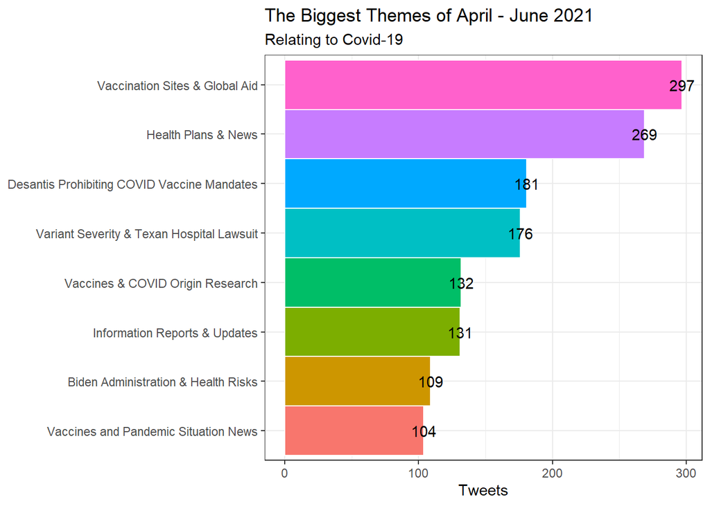

```r
  # gamma to find most dominant/prevalent topic during 2020
  gamma_2021_k10 <- lda2021_k10 %>%
    tidy(matrix = "gamma") %>%
    mutate(
    topic = recode(topic,
                     "1" = "Vaccination Sites & Global Aid",
                     "2" = "Health Plans & News",
                     "3" = "Desantis Prohibiting COVID Vaccine Mandates",
                     "4" = "Variant Severity & Texan Hospital Lawsuit",
                     "5" = "Information Reports & Updates",
                     "6" = "Vaccines & COVID Origin Research",
                     "7" = "Vaccines and Pandemic Situation News",
                     "8" = "Biden Administration & Health Risks"))

  dominant_topic_2021 <- gamma_2021_k10 %>%
    group_by(document) %>%
    slice_max(gamma, n = 1, with_ties = FALSE) %>%
    ungroup()

  topic_counts_2021 <- dominant_topic_2021 %>%
    count(topic, sort = TRUE) %>%
    mutate(topic = reorder(topic, n))

  ggplot(topic_counts_2021, aes(x = topic, y = n, fill = topic)) +
    geom_bar(stat = "identity", width = 1, color = "white", show.legend = F) +
    geom_text(aes(label = n)) +
    coord_flip() +
    labs(
      title = "The Biggest Themes of April - June 2021",
      subtitle = "Relating to Covid-19",
      fill = "Themes",
      x = NULL,
      y = "Tweets"
    ) + theme_bw()
```

In contrast to the previous topics found in tweets from mid-2020, the topics of 2021 is dominated by the existence of vaccines. That makes sense. There was no covid vaccine while investigating the tweets from 2020, since the first covid vaccine came out in the December of 2020.

**Some context:** At this time, we were under the Biden administration, which joins COVAX—program aimed at vaccinating people in low and middle income countries against COVID-19. Hence the most prevalent topic in 2021 regarding covid: Vaccination Sites & Global Aid. Vaccines were being distributed more, nationally and internationally. Also, by spring of 2021, about most age groups were able vaccinated, including senior citizens, adults, and adolescents.

There is strong pushback for vaccines in general, but during 2021, a variant like *delta* came to be. It was more contagious and more severe, but a large population of people still refused to wear masks and get vaccinated, fearing the long term complications due to limited testing. Desantis officially prohibited vaccine and mask mandates.

Ultimately, comparing the tweets and their topics with a one year gap highlights *vaccine developments*. In the 2020 tweets, Florida was just starting to reopen. And in 2021, life felt more normal, at least for the U.S. (hence less conversations on the national death reports.) The same cannot be said about lower income countries globally, which relied of other countries’ distribution of vaccines. Despite vaccines being a game changer, allowing the reopening of society to function so well, masks were and vaccines still are very controversial. The theme of vaccines heavily dominated several topics in 2021.

## Conclusion

From the Twitter analysis, topic modeling implied how people were generally talking about different subjects of the pandemic over time. For 2020, the strongest topics were health and test reports, pandemic updates, and government response. However, for 2021, we can observe a strong presence of vaccines, including its existence, distribution, further research, and pushback against requirements and mandates. Finally, sentiment analysis supported these shifts by showing changes in public mood across time, with fluctuations tied to major pandemic events such as surges, reopenings, and vaccine availability. Overall, this project suggests that by combining real data with public perception data, a further understanding can be met as to how behavior and outcomes shifted during COVID-19. These methods can all be applicable for public health emergencies to assess what people are discussing for policy decisions and better emergency preparedness.